# Projeto Final do Módulo: Linguagem R

Abrantes Araújo Silva Filho

FDTA

# 1. Tarefas do projeto final

O projeto final do módulo “Linguagem R” determina que seja criado um dataset com pelo menos 5 colunas numéricas e 3 colunas categóricas, através do uso de funções de criação de distribuições aleatórias.

Depois que o dataset for criado ele será gravado em disco e algumas tarefas básicas de análise de dados devem ser realizadas:

1. Calcular somas e médias através do uso das funções `apply`, `lapply`, `sapply`, etc.
2. Usar a função `split`
3. Criar gráficos simples
4. Colocar o projeto no [GitHub](http://github.com)

Nenhuma outra especificação a respeito de como deve ser o dataset foi fornecida então o que vale aqui é a criatividade na definição das variáveis do dataset e a demonstração de que o aluno aprendeu pelo menos o básio da linguagem R.

# 2. Conteúdo do meu dataset fictício

Parece claro para mim que a primeira coisa é definir o assunto (o *subject*) do dataset para depois definir quais seriam as variáveis (colunas) a serem simuladas. Assim, defini que meu dataset fictício se trata de uma *pesquisa a respeito de obesidade* em adultos jovens na qual foram coletados dados antropométricos, demográficos e de alguns fatores de risco.

As variáveis coletadas estão detalhadas na tabela abaixo (incluindo o tipo da variável, sua representação em R e outras informações importantes):

| Variável | Observações | Tipo | Representação no R |
| --- | --- | --- | --- |
| idade | Em anos completos | Dimensional de razão, discreta | Numeric |
| altura | Em metros (m) | Dimensional de razão, contínua | Numeric |
| peso | Em quilo (Kg) | Dimensional de razão, contínua | Numeric |
| imc | peso/altura<sup>2</sup> | Índice dimensional de razão, contínuo | Numeric |
| sexo | 1 = Masculino 2 = Feminino | Nominal | Unordered Factor |
| escolaridade | 0 = Analfabeto 1 = 1º grau completo 2 = 2º grau completo 3 = 3º grau completo 4 = mestrado 5 = doutorado 6 = pós-doutorado | Ordinal | Ordered Factor |
| profissao | 1 = Humanas 2 = Exatas 3 = Biológicas | Nominal | Unordered Factor |
| fumante | 0 = Não 1 = Sim | Binária | Ordered Factor |
| salario | Em reais (R$) | Dimensional de razão, contínua | Numeric |
| carros | Número de carros | Dimensional de razão, discreta | Numeric |
| filhos | Número de filhos | Dimensional de razão, discreta | Numeric |

# 3. Simulação das variáveis do dataset

Arbitrariamente decidi que o dataset conteria informações simuladas de 10.000 observações, retiradas aleatoriamente por algum processo de amostragem a partir de uma população de 100.000 indivídos. Esses parâmetros são definidos abaixo:

```r
n <- 10000
p <- 100000
```

## 3.1. Variáveis dimensionais

### 3.1.1. Idade

```r
set.seed(1234)
idade <- abs(round(rnorm(n, 35, 7),0))
summary(idade)
```

```
##    Min. 1st Qu.  Median    Mean 3rd Qu.    Max.
##   11.00   30.00   35.00   35.04   40.00   60.00
```

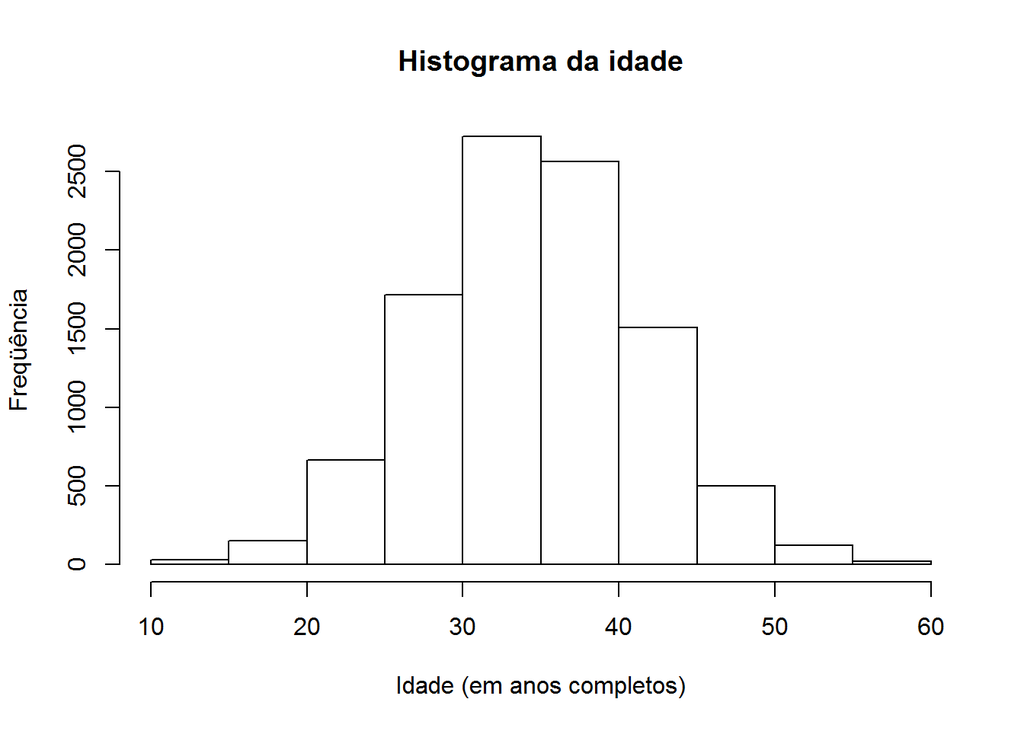

```r
hist(idade,
     main = "Histograma da idade",
     ylab = "Freqüência",
     xlab = "Idade (em anos completos)")
```

### 3.1.2. Altura

```r
set.seed(1234)
altura <- abs(round(rnorm(n, 1.50, 0.1), 2))
summary(altura)
```

```
##    Min. 1st Qu.  Median    Mean 3rd Qu.    Max.
##   1.160   1.430   1.500   1.501   1.570   1.860
```

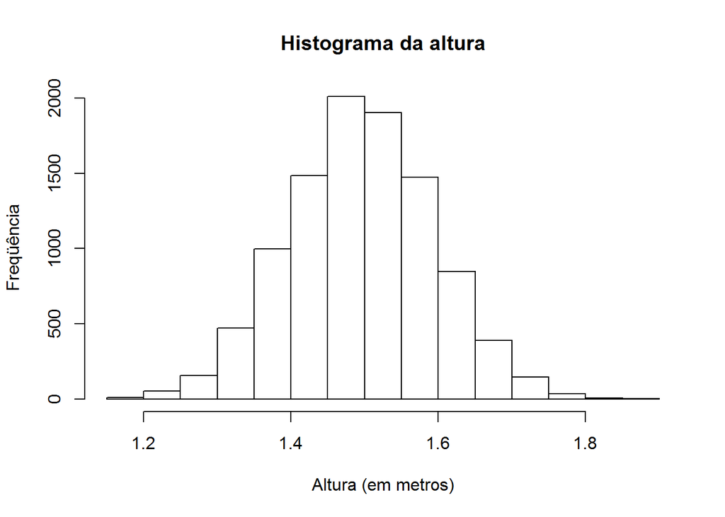

```r
hist(altura,
     main = "Histograma da altura",
     ylab = "Freqüência",
     xlab = "Altura (em metros)")
```

### 3.1.3. Peso

A variável peso (em Kg) seguiu a mesma lógica de simulação da altura, mas com média de 55 Kg e desvio padrão de 4 Kg (com duas casas decimais):

```r
set.seed(1234)
peso <- abs(round(rnorm(n, 55, 4), 2))
summary(peso)
```

```
##    Min. 1st Qu.  Median    Mean 3rd Qu.    Max.
##   41.42   52.36   55.02   55.02   57.68   69.47
```

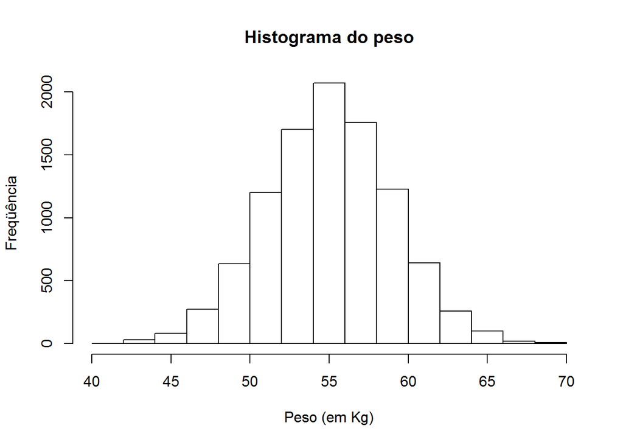

```r
hist(peso,
     main = "Histograma do peso",
     ylab = "Freqüência",
     xlab = "Peso (em Kg)")
```

### 3.1.4. Índice de massa corpórea

O cálculo do índice de massa corpórea (IMC) foi feito utiliando-se os dados já simulados do peso e da altura, utilizando-se a fórmula padrão: peso/(altura)<sup>2</sup> (os dados foram arredondados para 2 casas decimais)

```r
imc <- round(peso/altura^2, 2)
summary(imc)
```

```
##    Min. 1st Qu.  Median    Mean 3rd Qu.    Max.
##   20.01   23.49   24.44   24.52   25.46   30.78
```

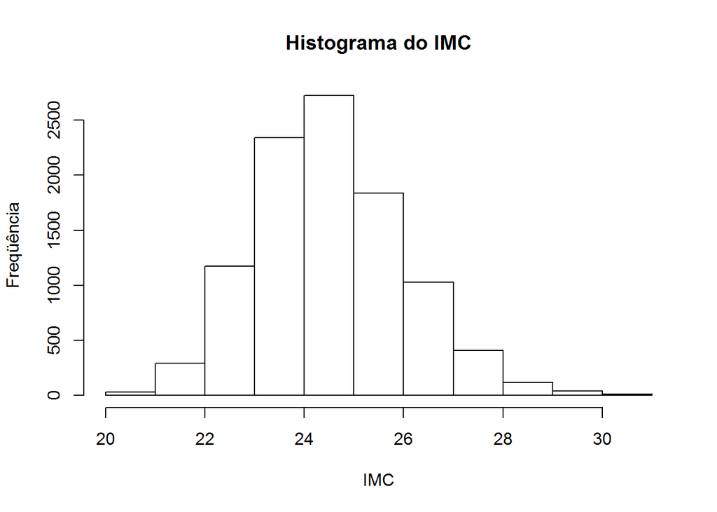

```r
hist(imc,
     main = "Histograma do IMC",
     ylab = "Freqüência",
     xlab = "IMC")
```

### 3.1.5. Salário

A variável salário (em reais) também foi simulada através de uma distribuição normal:

```r
set.seed(1234)
salario <- abs(round(rnorm(n, 3000, 400), 2))
summary(salario)
```

```
##    Min. 1st Qu.  Median    Mean 3rd Qu.    Max.
##    1642    2736    3002    3002    3268    4447
```

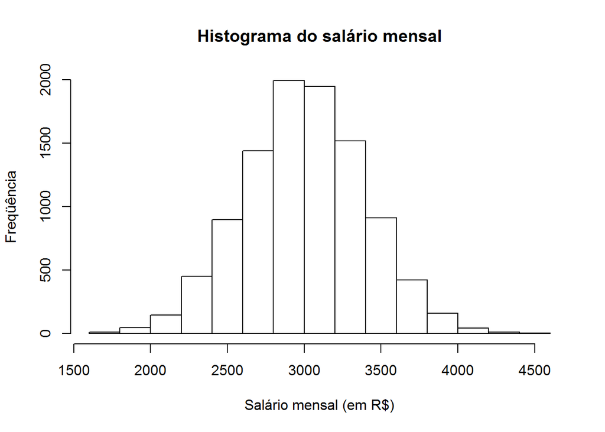

```r
hist(salario,
     main = "Histograma do salário mensal",
     ylab = "Freqüência",
     xlab = "Salário mensal (em R$)")
```

### 3.1.6. Carros

A variável número de carros foi simulada através de uma amostragem de valores de uma população de números (de 0 a 3). A população de valores foi criada com a função `rep` e a amostra foi retirada com a função `sample`.

```r
pop.carros <- rep(c(0,1,2,3), p)
set.seed(1234)
carros <- sample(pop.carros, n)
rm(pop.carros)
summary(carros)
```

```
##    Min. 1st Qu.  Median    Mean 3rd Qu.    Max.
##   0.000   0.000   1.000   1.492   2.000   3.000
```

```r
table(carros)
```

```
## carros
##    0    1    2    3
## 2513 2512 2512 2463
```

### 3.1.7. Filhos

A variável número de filhos foi simulada com a mesma estratégia utilizada para simular o número de carros (uso das funções `rep` e `sample`):

```r
pop.filhos <- rep(c(0, 1, 2), p)
set.seed(1234)
filhos <- sample(pop.filhos, n)
rm(pop.filhos)
summary(filhos)
```

```
##    Min. 1st Qu.  Median    Mean 3rd Qu.    Max.
##   0.000   0.000   1.000   1.002   2.000   2.000
```

```r
table(filhos)
```

```
## filhos
##    0    1    2
## 3331 3314 3355
```

## 3.2. Variáveis ordinais e binárias

### 3.2.1. Escolaridade

A variável escolaridade segue uma escala ordinal, do analfabeto até o pós-doutorado, e será representada no R por um fator ordenado. A estratégia de simulação adotada será o uso da função `rep` para criar uma população de números variando entre 0 a 6 (0 = analfabeto, 6 = pós-doutorado) e da função `sample` para selecionar uma amostra dessa população. Depois será criado um fator com a função `factor`, utiliando os labels adequados para cada level dos fatores:

```r
pop.escolaridade <- rep(c(0, 1, 2, 3, 4, 5, 6), p)
set.seed(1234)
escolaridade.temp <- sample(pop.escolaridade, n)
escolaridade <- factor(escolaridade.temp,
                       levels = c(0, 1, 2, 3, 4, 5, 6),
                       labels = c("Analfabeto", "1º Grau", "2º Grau", "3º Grau",
                                  "Mestrado", "Doutorado", "PósDoc"),
                       ordered = TRUE
                       )
rm(pop.escolaridade, escolaridade.temp)
str(escolaridade)
```

```
##  Ord.factor w/ 7 levels "Analfabeto"<"1º Grau"<..: 3 6 3 5 1 5 4 6 5 4 ...
```

```r
summary(escolaridade)
```

```
## Analfabeto    1º Grau    2º Grau    3º Grau   Mestrado  Doutorado
##       1459       1449       1399       1376       1398       1438
##     PósDoc
##       1481
```

```r
table(escolaridade)
```

```
## escolaridade
## Analfabeto    1º Grau    2º Grau    3º Grau   Mestrado  Doutorado
##       1459       1449       1399       1376       1398       1438
##     PósDoc
##       1481
```

### 3.2.2. Fumante

A variável fumante (binária) foi simulada através do uso de uma distribuição binomial para obter uma proprção de fumantes de aproximadamente 34% com o uso da função `rbinom`.

Notar que decidi usar um fator ordenado para a variável fumante já que uma variável binária como essa é, na verdade, um subconjunto de uma variável ordinal maior. A variável criada foi chamada de fumante.f (f de fator).

Notar também que mantive no dataset a variável fumante.n, que é a versão numérica da variável.

```r
set.seed(1234)
fumante.n <- rbinom(n, 1, .34)
fumante.f <- factor(fumante.n,
                    levels = c(0, 1),
                    labels = c("não", "sim"),
                    ordered = TRUE)
str(fumante.f)
```

```
##  Ord.factor w/ 2 levels "não"<"sim": 1 1 1 1 2 1 1 1 2 1 ...
```

```r
summary(fumante.f)
```

```
##  não  sim
## 6605 3395
```

```r
str(fumante.n)
```

```
##  int [1:10000] 0 0 0 0 1 0 0 0 1 0 ...
```

```r
mean(fumante.n)
```

```
## [1] 0.3395
```

## 3.3. Variáveis nominais

### 3.3.1. Sexo

A variável sexo foi simulada com o uso das funções `rep` e `sample` e depois transformada em um fator não ordenado:

```r
pop.sexo <- rep(c(1, 2), p)
set.seed(1234)
sexo.temp <- sample(pop.sexo, n)
sexo <- factor(sexo.temp,
               levels = c(1, 2),
               labels = c("M", "F"),
               ordered = FALSE)
rm(pop.sexo, sexo.temp)
str(sexo)
```

```
##  Factor w/ 2 levels "M","F": 1 2 2 1 2 1 2 1 2 2 ...
```

```r
summary(sexo)
```

```
##    M    F
## 5068 4932
```

### 3.3.3. Profissão

A variável profissão foi simulada com a mesma estratégia da variável sexo e depois transformada em um fator não ordenado:

```r
pop.profissao <- rep(0:2, p)
set.seed(1234)
profissao.temp <- sample(pop.profissao, n)
profissao <- factor(profissao.temp,
                    levels = c(0, 1, 2),
                    labels = c("Humanas", "Exatas", "Biológicas"),
                    ordered = FALSE
                    )
rm(pop.profissao, profissao.temp)
str(profissao)
```

```
##  Factor w/ 3 levels "Humanas","Exatas",..: 2 3 1 1 2 3 2 2 2 2 ...
```

```r
summary(profissao)
```

```
##    Humanas     Exatas Biológicas
##       3331       3314       3355
```

# 4. Criação do dataset

Com todas as variáveis já simuladas, para criar o dataset utilizamos a função `data.frame` para combinar todas as variáveis em um data frame do R. Também incluí aqui uma variável ID para identificar cada observação:

```r
df <- data.frame(id = 1:n,
                 idade,
                 altura,
                 peso,
                 imc,
                 sexo,
                 escolaridade,
                 profissao,
                 fumante.f,
                 fumante.n,
                 salario,
                 carros,
                 filhos
                 )
str(df)
```

```
## 'data.frame':    10000 obs. of  13 variables:
##  $ id          : int  1 2 3 4 5 6 7 8 9 10 ...
##  $ idade       : num  27 37 43 19 38 39 31 31 31 29 ...
##  $ altura      : num  1.38 1.53 1.61 1.27 1.54 1.55 1.44 1.45 1.44 1.41 ...
##  $ peso        : num  50.2 56.1 59.3 45.6 56.7 ...
##  $ imc         : num  26.3 24 22.9 28.3 23.9 ...
##  $ sexo        : Factor w/ 2 levels "M","F": 1 2 2 1 2 1 2 1 2 2 ...
##  $ escolaridade: Ord.factor w/ 7 levels "Analfabeto"<"1º Grau"<..: 3 6 3 5 1 5 4 6 5 4 ...
##  $ profissao   : Factor w/ 3 levels "Humanas","Exatas",..: 2 3 1 1 2 3 2 2 2 2 ...
##  $ fumante.f   : Ord.factor w/ 2 levels "não"<"sim": 1 1 1 1 2 1 1 1 2 1 ...
##  $ fumante.n   : int  0 0 0 0 1 0 0 0 1 0 ...
##  $ salario     : num  2517 3111 3434 2062 3172 ...
##  $ carros      : num  1 3 0 1 2 1 2 2 0 3 ...
##  $ filhos      : num  1 2 0 0 1 2 1 1 1 1 ...
```

Agora que o dataset está criado, vamos salvar em um diretório específico, usando as funções `setwd` e `write.table`:

```r
#setwd("~/repositoriosGit/ApoemaTraining/abrantesasf/projeto01")
write.table(df, file = "projeto01.csv", sep = ",", col.names = TRUE, fileEncoding = "UTF-8")
```

# 5. Uso de algumas funções com o dataset

Vamos calcular o sumário de todas as variáveis dimensionais:

```r
sapply(df[,c("idade", "altura", "peso", "imc", "salario", "carros", "filhos")],
       summary)
```

```
##         idade altura  peso   imc salario carros filhos
## Min.    11.00  1.160 41.42 20.01    1642  0.000  0.000
## 1st Qu. 30.00  1.430 52.36 23.49    2736  0.000  0.000
## Median  35.00  1.500 55.02 24.44    3002  1.000  1.000
## Mean    35.04  1.501 55.02 24.52    3002  1.492  1.002
## 3rd Qu. 40.00  1.570 57.68 25.46    3268  2.000  2.000
## Max.    60.00  1.860 69.47 30.78    4447  3.000  2.000
```

Agora vamos obter a soma de todas as variáveis dimensionais:

```r
apply(df[,c("idade", "altura", "peso", "imc", "salario", "carros", "filhos")],
      2,
      sum)
```

```
##       idade      altura        peso         imc     salario      carros
##   350405.00    15005.75   550244.99   245243.83 30024463.54    14925.00
##      filhos
##    10024.00
```

Tabelas das variáveis ordinais e nominais:

```r
sapply(df[,c("sexo", "escolaridade", "profissao", "fumante.f")],
       table)
```

```
## $sexo
##
##    M    F
## 5068 4932
##
## $escolaridade
##
## Analfabeto    1º Grau    2º Grau    3º Grau   Mestrado  Doutorado
##       1459       1449       1399       1376       1398       1438
##     PósDoc
##       1481
##
## $profissao
##
##    Humanas     Exatas Biológicas
##       3331       3314       3355
##
## $fumante.f
##
##  não  sim
## 6605 3395
```

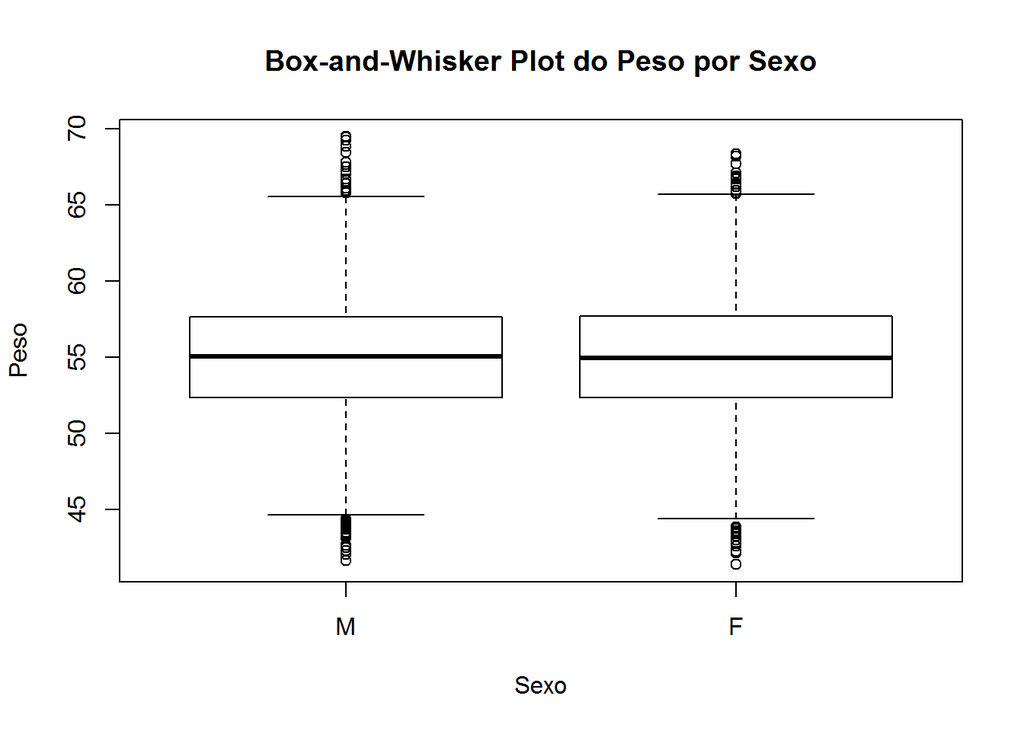

```r
boxplot(df$peso ~ df$sexo,
        main = "Box-and-Whisker Plot do Peso por Sexo",
        ylab = "Peso",
        xlab = "Sexo")
```

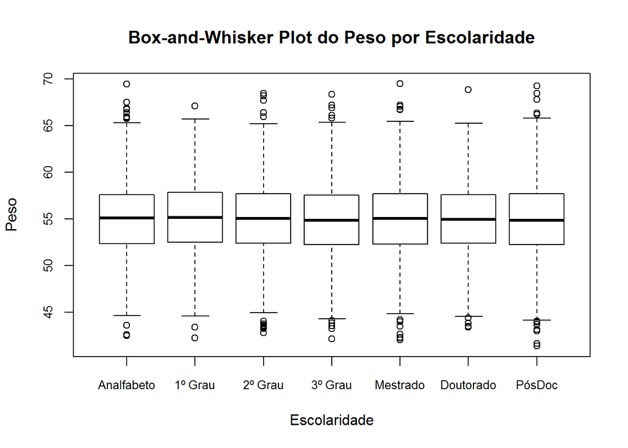

```r
boxplot(df$peso ~ df$escolaridade,
        main = "Box-and-Whisker Plot do Peso por Escolaridade",
        ylab = "Peso",
        xlab = "Escolaridade",
        cex.axis = 0.8)
```

Distribuição do peso e altura (histogramas e scatter plot):

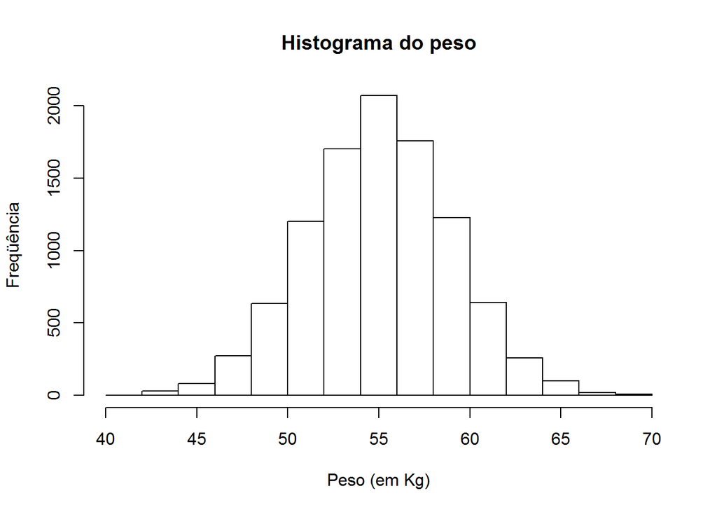

```r
hist(df$peso,
     main = "Histograma do peso",
     xlab = "Peso (em Kg)",
     ylab = "Freqüência")
```

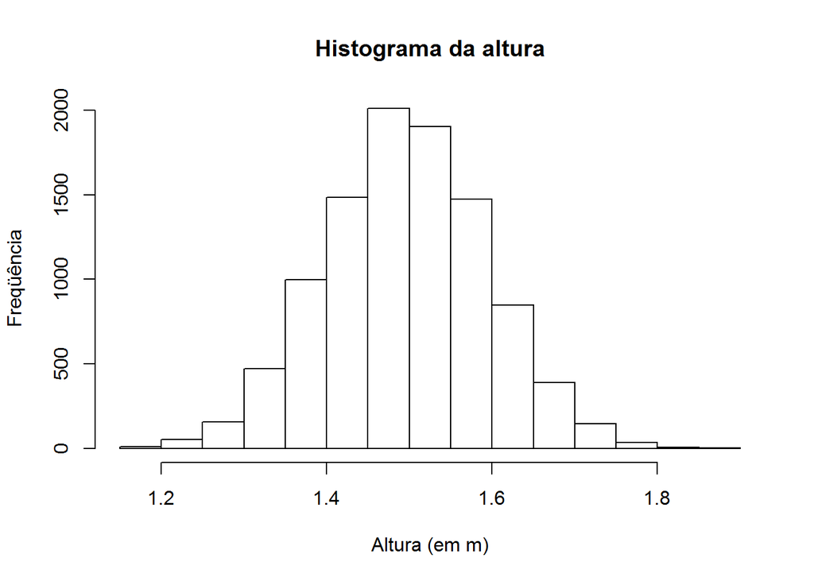

```r
hist(df$altura,
     main = "Histograma da altura",
     xlab = "Altura (em m)",
     ylab = "Freqüência")
```

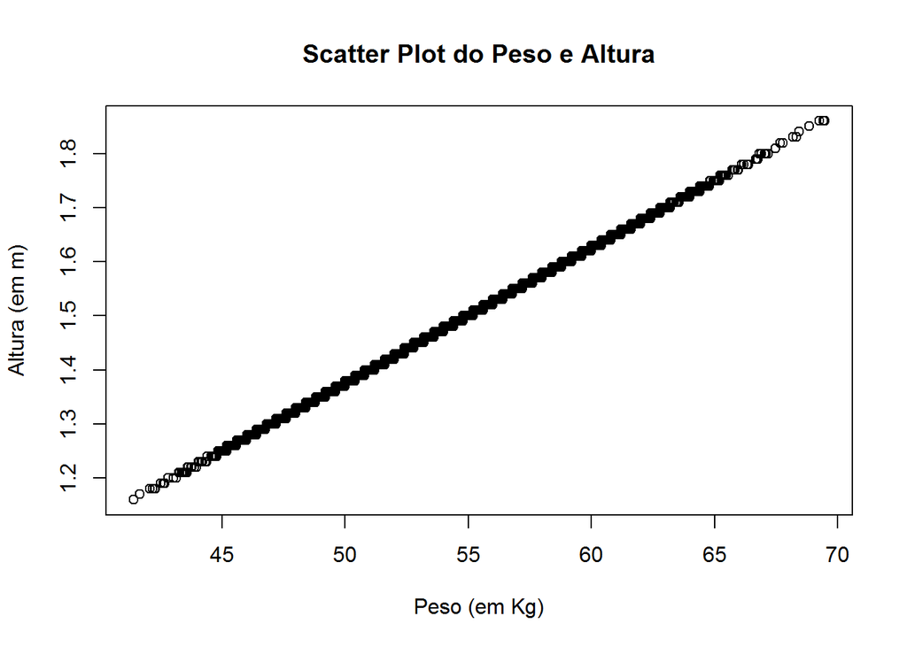

```r
plot(df$peso, df$altura,
     main = "Scatter Plot do Peso e Altura",
     xlab = "Peso (em Kg)",
     ylab = "Altura (em m)")
```

Devido ao método de simulação utilizado, a correlação entre o peso e a altura foi praticamente 1:

```r
cor(df$peso, df$altura)
```

```
## [1] 0.9995717
```